# Bank Client Data Exploration Markdown

Prabhudatta Mohapatra

October 7th, 2023

# 1 Code Chunk 1: Importing Libraries and Data, Data Insecption, Transformation, & Summary

```r
# 1.A

#install.packages('rmarkdown')
#install.packages('psych')
#install.packages('scatterplot3d')
#install.packages('caret')
library(rmarkdown)
library(psych)
library(scatterplot3d)
library(caret)
library(tidyverse)
library(dplyr)

mydir <- getwd()
setwd(mydir)

data <- read.csv("CD_additional_balanced.csv", stringsAsFactors = FALSE)

data %>% str()
```

```
## 'data.frame':    9280 obs. of  21 variables:
##  $ age           : int  41 49 49 41 45 42 39 28 44 42 ...
##  $ job           : chr  "blue-collar" "entrepreneur" "technician" "technician" ...
##  $ marital       : chr  "divorced" "married" "married" "married" ...
##  $ education     : chr  "basic.4y" "university.degree" "basic.9y" "professional.course" ...
##  $ default       : chr  "unknown" "unknown" "no" "unknown" ...
##  $ housing       : chr  "yes" "yes" "no" "yes" ...
##  $ loan          : chr  "no" "no" "no" "no" ...
##  $ contact       : chr  "telephone" "telephone" "telephone" "telephone" ...
##  $ month         : chr  "may" "may" "may" "may" ...
##  $ day_of_week   : chr  "mon" "mon" "mon" "mon" ...
##  $ duration      : int  1575 1042 1467 579 461 673 935 1201 1030 1623 ...
##  $ campaign      : int  1 1 1 1 1 2 3 1 1 1 ...
##  $ pdays         : int  999 999 999 999 999 999 999 999 999 999 ...
##  $ previous      : int  0 0 0 0 0 0 0 0 0 0 ...
##  $ poutcome      : chr  "nonexistent" "nonexistent" "nonexistent" "nonexistent" ...
##  $ emp.var.rate  : num  1.1 1.1 1.1 1.1 1.1 1.1 1.1 1.1 1.1 1.1 ...
##  $ cons.price.idx: num  94 94 94 94 94 ...
##  $ cons.conf.idx : num  -36.4 -36.4 -36.4 -36.4 -36.4 -36.4 -36.4 -36.4 -36.4 -36.4 ...
##  $ euribor3m     : num  4.86 4.86 4.86 4.86 4.86 ...
##  $ nr.employed   : num  5191 5191 5191 5191 5191 ...
##  $ y             : chr  "yes" "yes" "yes" "yes" ...
```

```r
# Inspecting first 10 rows of the data
data %>% head(10)
```

```
##    age          job  marital           education default housing loan   contact
## 1   41  blue-collar divorced            basic.4y unknown     yes   no telephone
## 2   49 entrepreneur  married   university.degree unknown     yes   no telephone
## 3   49   technician  married            basic.9y      no      no   no telephone
## 4   41   technician  married professional.course unknown     yes   no telephone
## 5   45  blue-collar  married            basic.9y unknown     yes   no telephone
## 6   42  blue-collar  married            basic.9y      no     yes  yes telephone
## 7   39    housemaid  married            basic.9y      no     yes   no telephone
## 8   28      unknown   single             unknown unknown     yes  yes telephone
## 9   44     services  married         high.school      no     yes   no telephone
## 10  42   technician  married professional.course      no      no   no telephone
##    month day_of_week duration campaign pdays previous    poutcome emp.var.rate
## 1    may         mon     1575        1   999        0 nonexistent          1.1
## 2    may         mon     1042        1   999        0 nonexistent          1.1
## 3    may         mon     1467        1   999        0 nonexistent          1.1
```

[output cut: 18 more lines]

```r
# 1.B

# Transforming character variables to factor variables
data<- data %>% mutate_if(is.character, as.factor)

#Structure of transformed data
data %>%  str()
```

```
## 'data.frame':    9280 obs. of  21 variables:
##  $ age           : int  41 49 49 41 45 42 39 28 44 42 ...
##  $ job           : Factor w/ 12 levels "admin.","blue-collar",..: 2 3 10 10 2 2 4 12 8 10 ...
##  $ marital       : Factor w/ 4 levels "divorced","married",..: 1 2 2 2 2 2 2 3 2 2 ...
##  $ education     : Factor w/ 8 levels "basic.4y","basic.6y",..: 1 7 3 6 3 3 3 8 4 6 ...
##  $ default       : Factor w/ 2 levels "no","unknown": 2 2 1 2 2 1 1 2 1 1 ...
##  $ housing       : Factor w/ 3 levels "no","unknown",..: 3 3 1 3 3 3 3 3 3 1 ...
##  $ loan          : Factor w/ 3 levels "no","unknown",..: 1 1 1 1 1 3 1 3 1 1 ...
##  $ contact       : Factor w/ 2 levels "cellular","telephone": 2 2 2 2 2 2 2 2 2 2 ...
##  $ month         : Factor w/ 10 levels "apr","aug","dec",..: 7 7 7 7 7 7 7 7 7 7 ...
##  $ day_of_week   : Factor w/ 5 levels "fri","mon","thu",..: 2 2 2 2 2 2 2 4 4 4 ...
##  $ duration      : int  1575 1042 1467 579 461 673 935 1201 1030 1623 ...
##  $ campaign      : int  1 1 1 1 1 2 3 1 1 1 ...
##  $ pdays         : int  999 999 999 999 999 999 999 999 999 999 ...
##  $ previous      : int  0 0 0 0 0 0 0 0 0 0 ...
##  $ poutcome      : Factor w/ 3 levels "failure","nonexistent",..: 2 2 2 2 2 2 2 2 2 2 ...
##  $ emp.var.rate  : num  1.1 1.1 1.1 1.1 1.1 1.1 1.1 1.1 1.1 1.1 ...
##  $ cons.price.idx: num  94 94 94 94 94 ...
##  $ cons.conf.idx : num  -36.4 -36.4 -36.4 -36.4 -36.4 -36.4 -36.4 -36.4 -36.4 -36.4 ...
##  $ euribor3m     : num  4.86 4.86 4.86 4.86 4.86 ...
##  $ nr.employed   : num  5191 5191 5191 5191 5191 ...
##  $ y             : Factor w/ 2 levels "no","yes": 2 2 2 2 2 2 2 2 2 2 ...
```

```r
#Summary of the transformed data

data %>% summary()
```

```
##       age                job           marital                   education
##  Min.   :17.0   admin.     :2517   divorced:1021   university.degree  :3007
##  1st Qu.:31.0   blue-collar:1769   married :5338   high.school        :2102
##  Median :38.0   technician :1459   single  :2900   professional.course:1190
##  Mean   :40.4   services   : 773   unknown :  21   basic.9y           :1177
##  3rd Qu.:48.0   management : 651                   basic.4y           : 895
##  Max.   :98.0   retired    : 595                   basic.6y           : 458
##                 (Other)    :1516                   (Other)            : 451
##     default        housing          loan           contact         month
##  no     :7824   no     :4104   no     :7688   cellular :6672   may    :2533
##  unknown:1456   unknown: 225   unknown: 225   telephone:2608   jul    :1477
##                 yes    :4951   yes    :1367                    aug    :1353
##                                                                jun    :1169
##                                                                nov    : 886
##                                                                apr    : 785
##                                                                (Other):1077
##  day_of_week    duration         campaign          pdays          previous
##  fri:1763    Min.   :   1.0   Min.   : 1.000   Min.   :  0.0   Min.   :0.0000
##  mon:1846    1st Qu.: 145.0   1st Qu.: 1.000   1st Qu.:999.0   1st Qu.:0.0000
##  thu:2000    Median : 265.0   Median : 2.000   Median :999.0   Median :0.0000
##  tue:1810    Mean   : 387.4   Mean   : 2.333   Mean   :887.3   Mean   :0.3153
##  wed:1861    3rd Qu.: 528.0   3rd Qu.: 3.000   3rd Qu.:999.0   3rd Qu.:0.0000
##              Max.   :4199.0   Max.   :39.000   Max.   :999.0   Max.   :6.0000
##
##         poutcome     emp.var.rate     cons.price.idx  cons.conf.idx
##  failure    :1074   Min.   :-3.4000   Min.   :92.20   Min.   :-50.80
##  nonexistent:7244   1st Qu.:-1.8000   1st Qu.:92.89   1st Qu.:-42.70
##  success    : 962   Median :-0.1000   Median :93.44   Median :-41.80
##                     Mean   :-0.4963   Mean   :93.48   Mean   :-40.22
##                     3rd Qu.: 1.4000   3rd Qu.:93.99   3rd Qu.:-36.40
##                     Max.   : 1.4000   Max.   :94.77   Max.   :-26.90
##
##    euribor3m      nr.employed     y
##  Min.   :0.634   Min.   :4964   no :4640
##  1st Qu.:1.244   1st Qu.:5076   yes:4640
##  Median :4.021   Median :5191
##  Mean   :2.960   Mean   :5135
##  3rd Qu.:4.959   3rd Qu.:5228
##  Max.   :5.045   Max.   :5228
##
```

```r
# checking missing values
data %>% summarize(across(everything(), ~ sum(is.na(.))))
```

```
##   age job marital education default housing loan contact month day_of_week
## 1   0   0       0         0       0       0    0       0     0           0
##   duration campaign pdays previous poutcome emp.var.rate cons.price.idx
## 1        0        0     0        0        0            0              0
##   cons.conf.idx euribor3m nr.employed y
## 1             0         0           0 0
```

## 1.1 Bank client data features

- The data frame has 9280 observations (rows) and 21 variables (columns). It’s a rectangular data set.
- There are 20 predictors and a single target variable which is ‘y’ means has the client subscribed a certified term deposit (CD)? (binary: “yes”,“no”).
- The data frame has variables with different data types such as int(age, duration, etc.), chr(job, marital, etc), and num(emp.var.rate, cons.price.idx, etc).
- The clients are aged between 17 and 98 with the mean age of client is 40.4
- Most of the clients are in administrative job.
- There are more married clients than divorced and single clients combined.
- There are more clients with university degree.
- Most of the clients never had a credit default.
- More than 50% of the clients have housing loan.
- On an average clients contact duration was 387.4 seconds.
- There are multiple variables which have data points values set to “unknown” such as marital, default, housing, and loan.
- This is a well balanced data set as the number of clients subscribed a certificate term deposit is same as the number of clients has not subscribed a certificate term deposit.

# 2 Code Chunk 2: Histogram, Boxplot, and Deciles (age, duration, campaign, pdays)

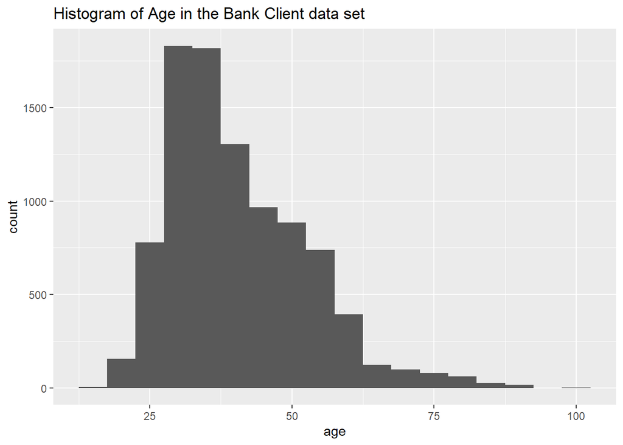

```r
# 2.A

# Histogram of age
data %>% ggplot() +
  geom_histogram(aes(x=age),binwidth = 5) +
  ggtitle('Histogram of Age in the Bank Client data set')
```

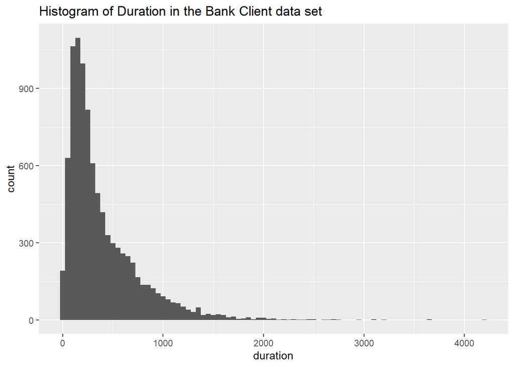

```r
# Histogram of duration
data %>% ggplot() +
  geom_histogram(aes(x=duration),binwidth = 50) +
  ggtitle('Histogram of Duration in the Bank Client data set')
```

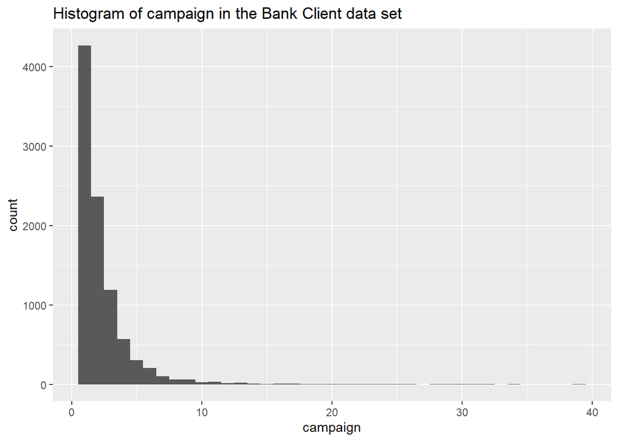

```r
# Histogram of campaign
data %>% ggplot() +
  geom_histogram(aes(x=campaign),binwidth = 1) +
  ggtitle('Histogram of campaign in the Bank Client data set')
```

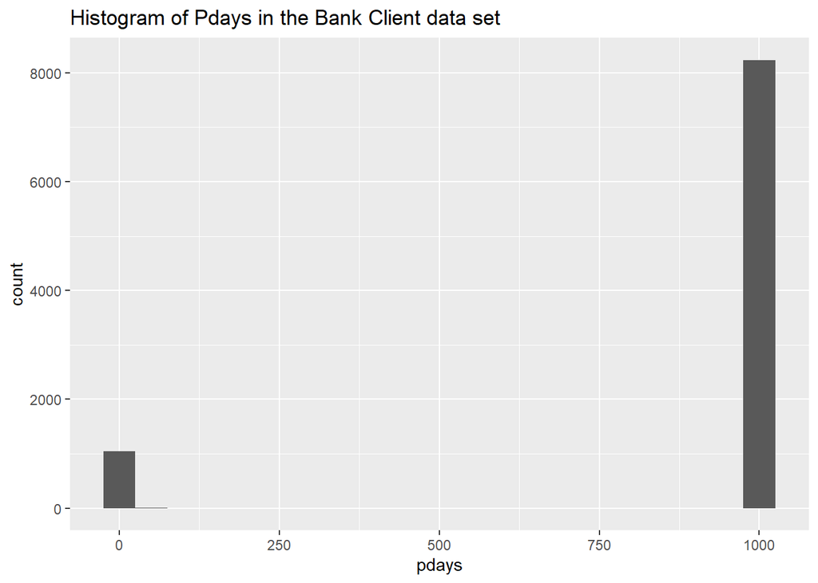

```r
# Histogram of pdays
data %>% ggplot() +
  geom_histogram(aes(x=pdays),binwidth = 50) +
  ggtitle('Histogram of Pdays in the Bank Client data set')
```

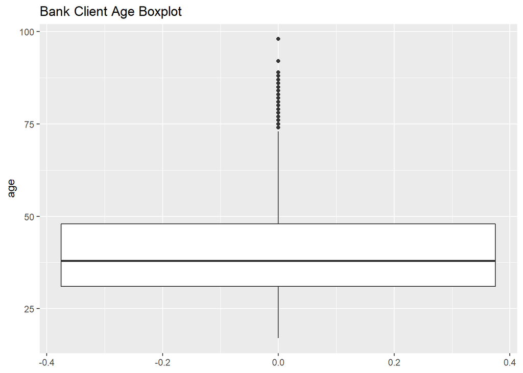

```r
# 2.B

# Boxplot for age
data %>%
  ggplot() +
  geom_boxplot(aes(y=age)) +
  ggtitle('Bank Client Age Boxplot')
```

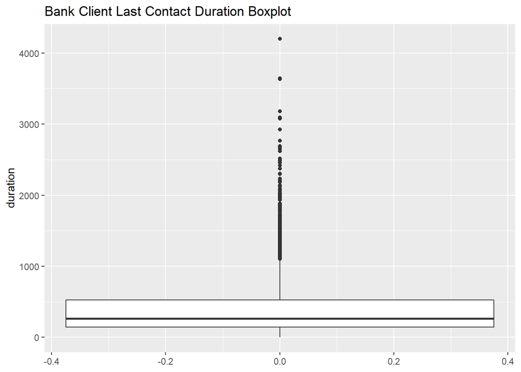

```r
# Boxplot for duration
data %>%
  ggplot() +
  geom_boxplot(aes(y=duration)) +
  ggtitle('Bank Client Last Contact Duration Boxplot')
```